# CYCLISTIC_FULL_YEAR_ANALYSIS

LAVANY JADHAV

6/26/2021

# STEP 1 : Loading the package

```r
library(tidyverse)
library(lubridate)
```

# STEP 2 : Loading the data

```r
q2_2019 <- read_csv("D:\\Data Analytics certification\\Case Study\\Dataset\\2019_All_quaters_Raw_Dataset\\Divvy_Trips_2019_Q2.csv")
q3_2019 <- read_csv("D:\\Data Analytics certification\\Case Study\\Dataset\\2019_All_quaters_Raw_Dataset\\Divvy_Trips_2019_Q3.csv")
q4_2019 <- read_csv("D:\\Data Analytics certification\\Case Study\\Dataset\\2019_All_quaters_Raw_Dataset\\Divvy_Trips_2019_Q4.csv")
q1_2020 <- read_csv("D:\\Data Analytics certification\\Case Study\\Dataset\\2019_All_quaters_Raw_Dataset\\Divvy_Trips_2019_Q1.csv")
```

# STEP 3 : Reading table schema

```r
colnames(q3_2019)
```

```
##  [1] "trip_id"           "start_time"        "end_time"
##  [4] "bikeid"            "tripduration"      "from_station_id"
##  [7] "from_station_name" "to_station_id"     "to_station_name"
## [10] "usertype"          "gender"            "birthyear"
```

```r
colnames(q4_2019)
```

```
##  [1] "trip_id"           "start_time"        "end_time"
##  [4] "bikeid"            "tripduration"      "from_station_id"
##  [7] "from_station_name" "to_station_id"     "to_station_name"
## [10] "usertype"          "gender"            "birthyear"
```

```r
colnames(q2_2019)
```

```
##  [1] "01 - Rental Details Rental ID"
##  [2] "01 - Rental Details Local Start Time"
##  [3] "01 - Rental Details Local End Time"
##  [4] "01 - Rental Details Bike ID"
##  [5] "01 - Rental Details Duration In Seconds Uncapped"
##  [6] "03 - Rental Start Station ID"
##  [7] "03 - Rental Start Station Name"
##  [8] "02 - Rental End Station ID"
##  [9] "02 - Rental End Station Name"
## [10] "User Type"
## [11] "Member Gender"
## [12] "05 - Member Details Member Birthday Year"
```

```r
colnames(q1_2020)
```

```
##  [1] "trip_id"           "start_time"        "end_time"
##  [4] "bikeid"            "tripduration"      "from_station_id"
##  [7] "from_station_name" "to_station_id"     "to_station_name"
## [10] "usertype"          "gender"            "birthyear"
```

# STEP 4 : Rename the header of the table

```r
(q4_2019 <- rename(q4_2019
                   ,ride_id = trip_id
                   ,rideable_type = bikeid
                   ,started_at = start_time
                   ,ended_at = end_time
                   ,start_station_name = from_station_name
                   ,start_station_id = from_station_id
                   ,end_station_name = to_station_name
                   ,end_station_id = to_station_id
                   ,member_casual = usertype))
```

```
## # A tibble: 704,054 x 12
##     ride_id started_at          ended_at            rideable_type tripduration
##       <dbl> <dttm>              <dttm>                      <dbl>        <dbl>
##  1 25223640 2019-10-01 00:01:39 2019-10-01 00:17:20          2215          940
##  2 25223641 2019-10-01 00:02:16 2019-10-01 00:06:34          6328          258
##  3 25223642 2019-10-01 00:04:32 2019-10-01 00:18:43          3003          850
##  4 25223643 2019-10-01 00:04:32 2019-10-01 00:43:43          3275         2350
##  5 25223644 2019-10-01 00:04:34 2019-10-01 00:35:42          5294         1867
##  6 25223645 2019-10-01 00:04:38 2019-10-01 00:10:51          1891          373
##  7 25223646 2019-10-01 00:04:52 2019-10-01 00:22:45          1061         1072
##  8 25223647 2019-10-01 00:04:57 2019-10-01 00:29:16          1274         1458
##  9 25223648 2019-10-01 00:05:20 2019-10-01 00:29:18          6011         1437
## 10 25223649 2019-10-01 00:05:20 2019-10-01 02:23:46          2957         8306
## # ... with 704,044 more rows, and 7 more variables: start_station_id <dbl>,
## #   start_station_name <chr>, end_station_id <dbl>, end_station_name <chr>,
## #   member_casual <chr>, gender <chr>, birthyear <dbl>
```

```r
(q3_2019 <- rename(q3_2019
                   ,ride_id = trip_id
                   ,rideable_type = bikeid
                   ,started_at = start_time
                   ,ended_at = end_time
                   ,start_station_name = from_station_name
                   ,start_station_id = from_station_id
                   ,end_station_name = to_station_name
                   ,end_station_id = to_station_id
                   ,member_casual = usertype))
```

```
## # A tibble: 1,640,718 x 12
##     ride_id started_at          ended_at            rideable_type tripduration
##       <dbl> <dttm>              <dttm>                      <dbl>        <dbl>
##  1 23479388 2019-07-01 00:00:27 2019-07-01 00:20:41          3591         1214
##  2 23479389 2019-07-01 00:01:16 2019-07-01 00:18:44          5353         1048
##  3 23479390 2019-07-01 00:01:48 2019-07-01 00:27:42          6180         1554
##  4 23479391 2019-07-01 00:02:07 2019-07-01 00:27:10          5540         1503
##  5 23479392 2019-07-01 00:02:13 2019-07-01 00:22:26          6014         1213
##  6 23479393 2019-07-01 00:02:21 2019-07-01 00:07:31          4941          310
##  7 23479394 2019-07-01 00:02:24 2019-07-01 00:23:12          3770         1248
##  8 23479395 2019-07-01 00:02:26 2019-07-01 00:28:16          5442         1550
##  9 23479396 2019-07-01 00:02:34 2019-07-01 00:28:57          2957         1583
## 10 23479397 2019-07-01 00:02:45 2019-07-01 00:29:14          6091         1589
## # ... with 1,640,708 more rows, and 7 more variables: start_station_id <dbl>,
## #   start_station_name <chr>, end_station_id <dbl>, end_station_name <chr>,
## #   member_casual <chr>, gender <chr>, birthyear <dbl>
```

```r
(q2_2019 <- rename(q2_2019
                   ,ride_id = "01 - Rental Details Rental ID"
                   ,rideable_type = "01 - Rental Details Bike ID"
                   ,started_at = "01 - Rental Details Local Start Time"
                   ,ended_at = "01 - Rental Details Local End Time"
                   ,start_station_name = "03 - Rental Start Station Name"
                   ,start_station_id = "03 - Rental Start Station ID"
                   ,end_station_name = "02 - Rental End Station Name"
                   ,end_station_id = "02 - Rental End Station ID"
                   ,member_casual = "User Type"))
```

```
## # A tibble: 1,108,163 x 12
##     ride_id started_at          ended_at            rideable_type
##       <dbl> <dttm>              <dttm>                      <dbl>
##  1 22178529 2019-04-01 00:02:22 2019-04-01 00:09:48          6251
##  2 22178530 2019-04-01 00:03:02 2019-04-01 00:20:30          6226
##  3 22178531 2019-04-01 00:11:07 2019-04-01 00:15:19          5649
##  4 22178532 2019-04-01 00:13:01 2019-04-01 00:18:58          4151
##  5 22178533 2019-04-01 00:19:26 2019-04-01 00:36:13          3270
##  6 22178534 2019-04-01 00:19:39 2019-04-01 00:23:56          3123
##  7 22178535 2019-04-01 00:26:33 2019-04-01 00:35:41          6418
##  8 22178536 2019-04-01 00:29:48 2019-04-01 00:36:11          4513
##  9 22178537 2019-04-01 00:32:07 2019-04-01 01:07:44          3280
## 10 22178538 2019-04-01 00:32:19 2019-04-01 01:07:39          5534
## # ... with 1,108,153 more rows, and 8 more variables:
## #   01 - Rental Details Duration In Seconds Uncapped <dbl>,
## #   start_station_id <dbl>, start_station_name <chr>, end_station_id <dbl>,
## #   end_station_name <chr>, member_casual <chr>, Member Gender <chr>,
## #   05 - Member Details Member Birthday Year <dbl>
```

# STEP 5 : Inspecting the DataFrames

```r
str(q1_2020)
```

```
## spec_tbl_df [365,069 x 12] (S3: spec_tbl_df/tbl_df/tbl/data.frame)
##  $ trip_id          : num [1:365069] 21742443 21742444 21742445 21742446 21742447 ...
##  $ start_time       : POSIXct[1:365069], format: "2019-01-01 00:04:37" "2019-01-01 00:08:13" ...
##  $ end_time         : POSIXct[1:365069], format: "2019-01-01 00:11:07" "2019-01-01 00:15:34" ...
##  $ bikeid           : num [1:365069] 2167 4386 1524 252 1170 ...
##  $ tripduration     : num [1:365069] 390 441 829 1783 364 ...
##  $ from_station_id  : num [1:365069] 199 44 15 123 173 98 98 211 150 268 ...
##  $ from_station_name: chr [1:365069] "Wabash Ave & Grand Ave" "State St & Randolph St" "Racine Ave & 18th St" "California Ave & Milwaukee Ave" ...
##  $ to_station_id    : num [1:365069] 84 624 644 176 35 49 49 142 148 141 ...
##  $ to_station_name  : chr [1:365069] "Milwaukee Ave & Grand Ave" "Dearborn St & Van Buren St (*)" "Western Ave & Fillmore St (*)" "Clark St & Elm St" ...
##  $ usertype         : chr [1:365069] "Subscriber" "Subscriber" "Subscriber" "Subscriber" ...
##  $ gender           : chr [1:365069] "Male" "Female" "Female" "Male" ...
##  $ birthyear        : num [1:365069] 1989 1990 1994 1993 1994 ...
##  - attr(*, "spec")=
##   .. cols(
##   ..   trip_id = col_double(),
##   ..   start_time = col_datetime(format = ""),
##   ..   end_time = col_datetime(format = ""),
##   ..   bikeid = col_double(),
##   ..   tripduration = col_number(),
##   ..   from_station_id = col_double(),
##   ..   from_station_name = col_character(),
##   ..   to_station_id = col_double(),
##   ..   to_station_name = col_character(),
##   ..   usertype = col_character(),
##   ..   gender = col_character(),
##   ..   birthyear = col_double()
##   .. )
```

```r
str(q4_2019)
```

```
## spec_tbl_df [704,054 x 12] (S3: spec_tbl_df/tbl_df/tbl/data.frame)
##  $ ride_id           : num [1:704054] 25223640 25223641 25223642 25223643 25223644 ...
##  $ started_at        : POSIXct[1:704054], format: "2019-10-01 00:01:39" "2019-10-01 00:02:16" ...
##  $ ended_at          : POSIXct[1:704054], format: "2019-10-01 00:17:20" "2019-10-01 00:06:34" ...
##  $ rideable_type     : num [1:704054] 2215 6328 3003 3275 5294 ...
##  $ tripduration      : num [1:704054] 940 258 850 2350 1867 ...
##  $ start_station_id  : num [1:704054] 20 19 84 313 210 156 84 156 156 336 ...
##  $ start_station_name: chr [1:704054] "Sheffield Ave & Kingsbury St" "Throop (Loomis) St & Taylor St" "Milwaukee Ave & Grand Ave" "Lakeview Ave & Fullerton Pkwy" ...
##  $ end_station_id    : num [1:704054] 309 241 199 290 382 226 142 463 463 336 ...
##  $ end_station_name  : chr [1:704054] "Leavitt St & Armitage Ave" "Morgan St & Polk St" "Wabash Ave & Grand Ave" "Kedzie Ave & Palmer Ct" ...
##  $ member_casual     : chr [1:704054] "Subscriber" "Subscriber" "Subscriber" "Subscriber" ...
##  $ gender            : chr [1:704054] "Male" "Male" "Female" "Male" ...
##  $ birthyear         : num [1:704054] 1987 1998 1991 1990 1987 ...
##  - attr(*, "spec")=
##   .. cols(
##   ..   trip_id = col_double(),
##   ..   start_time = col_datetime(format = ""),
##   ..   end_time = col_datetime(format = ""),
##   ..   bikeid = col_double(),
##   ..   tripduration = col_number(),
##   ..   from_station_id = col_double(),
##   ..   from_station_name = col_character(),
##   ..   to_station_id = col_double(),
##   ..   to_station_name = col_character(),
##   ..   usertype = col_character(),
##   ..   gender = col_character(),
##   ..   birthyear = col_double()
##   .. )
```

```r
str(q3_2019)
```

```
## spec_tbl_df [1,640,718 x 12] (S3: spec_tbl_df/tbl_df/tbl/data.frame)
##  $ ride_id           : num [1:1640718] 23479388 23479389 23479390 23479391 23479392 ...
##  $ started_at        : POSIXct[1:1640718], format: "2019-07-01 00:00:27" "2019-07-01 00:01:16" ...
##  $ ended_at          : POSIXct[1:1640718], format: "2019-07-01 00:20:41" "2019-07-01 00:18:44" ...
##  $ rideable_type     : num [1:1640718] 3591 5353 6180 5540 6014 ...
##  $ tripduration      : num [1:1640718] 1214 1048 1554 1503 1213 ...
##  $ start_station_id  : num [1:1640718] 117 381 313 313 168 300 168 313 43 43 ...
##  $ start_station_name: chr [1:1640718] "Wilton Ave & Belmont Ave" "Western Ave & Monroe St" "Lakeview Ave & Fullerton Pkwy" "Lakeview Ave & Fullerton Pkwy" ...
##  $ end_station_id    : num [1:1640718] 497 203 144 144 62 232 62 144 195 195 ...
##  $ end_station_name  : chr [1:1640718] "Kimball Ave & Belmont Ave" "Western Ave & 21st St" "Larrabee St & Webster Ave" "Larrabee St & Webster Ave" ...
##  $ member_casual     : chr [1:1640718] "Subscriber" "Customer" "Customer" "Customer" ...
##  $ gender            : chr [1:1640718] "Male" NA NA NA ...
##  $ birthyear         : num [1:1640718] 1992 NA NA NA NA ...
##  - attr(*, "spec")=
##   .. cols(
##   ..   trip_id = col_double(),
##   ..   start_time = col_datetime(format = ""),
##   ..   end_time = col_datetime(format = ""),
##   ..   bikeid = col_double(),
##   ..   tripduration = col_number(),
##   ..   from_station_id = col_double(),
##   ..   from_station_name = col_character(),
##   ..   to_station_id = col_double(),
##   ..   to_station_name = col_character(),
##   ..   usertype = col_character(),
##   ..   gender = col_character(),
##   ..   birthyear = col_double()
##   .. )
```

```r
str(q2_2019)
```

```
## spec_tbl_df [1,108,163 x 12] (S3: spec_tbl_df/tbl_df/tbl/data.frame)
##  $ ride_id                                         : num [1:1108163] 22178529 22178530 22178531 22178532 22178533 ...
##  $ started_at                                      : POSIXct[1:1108163], format: "2019-04-01 00:02:22" "2019-04-01 00:03:02" ...
##  $ ended_at                                        : POSIXct[1:1108163], format: "2019-04-01 00:09:48" "2019-04-01 00:20:30" ...
##  $ rideable_type                                   : num [1:1108163] 6251 6226 5649 4151 3270 ...
##  $ 01 - Rental Details Duration In Seconds Uncapped: num [1:1108163] 446 1048 252 357 1007 ...
##  $ start_station_id                                : num [1:1108163] 81 317 283 26 202 420 503 260 211 211 ...
##  $ start_station_name                              : chr [1:1108163] "Daley Center Plaza" "Wood St & Taylor St" "LaSalle St & Jackson Blvd" "McClurg Ct & Illinois St" ...
##  $ end_station_id                                  : num [1:1108163] 56 59 174 133 129 426 500 499 211 211 ...
##  $ end_station_name                                : chr [1:1108163] "Desplaines St & Kinzie St" "Wabash Ave & Roosevelt Rd" "Canal St & Madison St" "Kingsbury St & Kinzie St" ...
##  $ member_casual                                   : chr [1:1108163] "Subscriber" "Subscriber" "Subscriber" "Subscriber" ...
##  $ Member Gender                                   : chr [1:1108163] "Male" "Female" "Male" "Male" ...
##  $ 05 - Member Details Member Birthday Year        : num [1:1108163] 1975 1984 1990 1993 1992 ...
##  - attr(*, "spec")=
##   .. cols(
##   ..   `01 - Rental Details Rental ID` = col_double(),
##   ..   `01 - Rental Details Local Start Time` = col_datetime(format = ""),
##   ..   `01 - Rental Details Local End Time` = col_datetime(format = ""),
##   ..   `01 - Rental Details Bike ID` = col_double(),
##   ..   `01 - Rental Details Duration In Seconds Uncapped` = col_number(),
##   ..   `03 - Rental Start Station ID` = col_double(),
##   ..   `03 - Rental Start Station Name` = col_character(),
##   ..   `02 - Rental End Station ID` = col_double(),
##   ..   `02 - Rental End Station Name` = col_character(),
##   ..   `User Type` = col_character(),
##   ..   `Member Gender` = col_character(),
##   ..   `05 - Member Details Member Birthday Year` = col_double()
##   .. )
```

# STEP 6 : Processing the data

Convert ride_id and rideable_type to character so that they can stack correctly

```r
q4_2019 <-  mutate(q4_2019, ride_id = as.character(ride_id)
                   ,rideable_type = as.character(rideable_type))
q3_2019 <-  mutate(q3_2019, ride_id = as.character(ride_id)
                   ,rideable_type = as.character(rideable_type))
q2_2019 <-  mutate(q2_2019, ride_id = as.character(ride_id)
                   ,rideable_type = as.character(rideable_type))
```

Stack individual quarter’s data frames into one big data frame

```r
all_trips <- bind_rows(q2_2019, q3_2019, q4_2019, q1_2020)
colnames(all_trips)
```

```
##  [1] "ride_id"
##  [2] "started_at"
##  [3] "ended_at"
##  [4] "rideable_type"
##  [5] "01 - Rental Details Duration In Seconds Uncapped"
##  [6] "start_station_id"
##  [7] "start_station_name"
##  [8] "end_station_id"
##  [9] "end_station_name"
## [10] "member_casual"
## [11] "Member Gender"
## [12] "05 - Member Details Member Birthday Year"
## [13] "tripduration"
## [14] "gender"
## [15] "birthyear"
## [16] "trip_id"
## [17] "start_time"
## [18] "end_time"
## [19] "bikeid"
## [20] "from_station_id"
## [21] "from_station_name"
## [22] "to_station_id"
## [23] "to_station_name"
## [24] "usertype"
```

```r
all_trips <- all_trips %>%
  select(-c(birthyear, gender, "01 - Rental Details Duration In Seconds Uncapped", "05 - Member Details Member Birthday Year", "Member Gender", "tripduration"))
```

# Step 7 : inspect new table

```r
colnames(all_trips)  #List of column names
```

```
##  [1] "ride_id"            "started_at"         "ended_at"
##  [4] "rideable_type"      "start_station_id"   "start_station_name"
##  [7] "end_station_id"     "end_station_name"   "member_casual"
## [10] "trip_id"            "start_time"         "end_time"
## [13] "bikeid"             "from_station_id"    "from_station_name"
## [16] "to_station_id"      "to_station_name"    "usertype"
```

```r
nrow(all_trips)  #How many rows are in data frame?
```

```
## [1] 3818004
```

```r
dim(all_trips)  #Dimensions of the data frame?
```

```
## [1] 3818004      18
```

```r
head(all_trips)  #See the first 6 rows of data frame.  Also tail(qs_raw)
```

```
## # A tibble: 6 x 18
##   ride_id started_at          ended_at            rideable_type start_station_id
##   <chr>   <dttm>              <dttm>              <chr>                    <dbl>
## 1 221785~ 2019-04-01 00:02:22 2019-04-01 00:09:48 6251                        81
## 2 221785~ 2019-04-01 00:03:02 2019-04-01 00:20:30 6226                       317
## 3 221785~ 2019-04-01 00:11:07 2019-04-01 00:15:19 5649                       283
## 4 221785~ 2019-04-01 00:13:01 2019-04-01 00:18:58 4151                        26
## 5 221785~ 2019-04-01 00:19:26 2019-04-01 00:36:13 3270                       202
## 6 221785~ 2019-04-01 00:19:39 2019-04-01 00:23:56 3123                       420
## # ... with 13 more variables: start_station_name <chr>, end_station_id <dbl>,
## #   end_station_name <chr>, member_casual <chr>, trip_id <dbl>,
## #   start_time <dttm>, end_time <dttm>, bikeid <dbl>, from_station_id <dbl>,
## #   from_station_name <chr>, to_station_id <dbl>, to_station_name <chr>,
## #   usertype <chr>
```

```r
str(all_trips)  #See list of columns and data types (numeric, character, etc)
```

```
## tibble [3,818,004 x 18] (S3: tbl_df/tbl/data.frame)
##  $ ride_id           : chr [1:3818004] "22178529" "22178530" "22178531" "22178532" ...
##  $ started_at        : POSIXct[1:3818004], format: "2019-04-01 00:02:22" "2019-04-01 00:03:02" ...
##  $ ended_at          : POSIXct[1:3818004], format: "2019-04-01 00:09:48" "2019-04-01 00:20:30" ...
##  $ rideable_type     : chr [1:3818004] "6251" "6226" "5649" "4151" ...
##  $ start_station_id  : num [1:3818004] 81 317 283 26 202 420 503 260 211 211 ...
##  $ start_station_name: chr [1:3818004] "Daley Center Plaza" "Wood St & Taylor St" "LaSalle St & Jackson Blvd" "McClurg Ct & Illinois St" ...
##  $ end_station_id    : num [1:3818004] 56 59 174 133 129 426 500 499 211 211 ...
##  $ end_station_name  : chr [1:3818004] "Desplaines St & Kinzie St" "Wabash Ave & Roosevelt Rd" "Canal St & Madison St" "Kingsbury St & Kinzie St" ...
##  $ member_casual     : chr [1:3818004] "Subscriber" "Subscriber" "Subscriber" "Subscriber" ...
##  $ trip_id           : num [1:3818004] NA NA NA NA NA NA NA NA NA NA ...
##  $ start_time        : POSIXct[1:3818004], format: NA NA ...
##  $ end_time          : POSIXct[1:3818004], format: NA NA ...
##  $ bikeid            : num [1:3818004] NA NA NA NA NA NA NA NA NA NA ...
##  $ from_station_id   : num [1:3818004] NA NA NA NA NA NA NA NA NA NA ...
##  $ from_station_name : chr [1:3818004] NA NA NA NA ...
##  $ to_station_id     : num [1:3818004] NA NA NA NA NA NA NA NA NA NA ...
##  $ to_station_name   : chr [1:3818004] NA NA NA NA ...
##  $ usertype          : chr [1:3818004] NA NA NA NA ...
```

```r
summary(all_trips)  #Statistical summary of data. Mainly for numerics
```

```
##    ride_id            started_at                     ended_at
##  Length:3818004     Min.   :2019-04-01 00:02:22   Min.   :2019-04-01 00:09:48
##  Class :character   1st Qu.:2019-06-16 10:35:43   1st Qu.:2019-06-16 10:57:45
##  Mode  :character   Median :2019-08-03 18:32:36   Median :2019-08-03 19:04:32
##                     Mean   :2019-08-04 18:25:08   Mean   :2019-08-04 18:50:05
##                     3rd Qu.:2019-09-20 08:17:03   3rd Qu.:2019-09-20 08:33:09
##                     Max.   :2019-12-31 23:57:17   Max.   :2020-01-21 13:54:35
##                     NA's   :365069                NA's   :365069
##  rideable_type      start_station_id start_station_name end_station_id
##  Length:3818004     Min.   :  1      Length:3818004     Min.   :  1.0
##  Class :character   1st Qu.: 77      Class :character   1st Qu.: 77.0
##  Mode  :character   Median :174      Mode  :character   Median :174.0
##                     Mean   :202                         Mean   :203.1
##                     3rd Qu.:289                         3rd Qu.:291.0
##                     Max.   :673                         Max.   :673.0
##                     NA's   :365069                      NA's   :365069
##  end_station_name   member_casual         trip_id
##  Length:3818004     Length:3818004     Min.   :21742443
##  Class :character   Class :character   1st Qu.:21848765
##  Mode  :character   Mode  :character   Median :21961829
##                                        Mean   :21960872
##                                        3rd Qu.:22071823
##                                        Max.   :22178528
##                                        NA's   :3452935
##    start_time                     end_time                       bikeid
##  Min.   :2019-01-01 00:04:37   Min.   :2019-01-01 00:11:07   Min.   :   1
##  1st Qu.:2019-01-23 05:26:54   1st Qu.:2019-01-23 05:49:40   1st Qu.:1777
##  Median :2019-02-25 07:52:56   Median :2019-02-25 08:03:50   Median :3489
##  Mean   :2019-02-19 21:43:15   Mean   :2019-02-19 22:00:11   Mean   :3429
##  3rd Qu.:2019-03-17 16:52:47   3rd Qu.:2019-03-17 17:16:16   3rd Qu.:5157
##  Max.   :2019-03-31 23:53:48   Max.   :2019-06-17 16:04:35   Max.   :6471
##  NA's   :3452935               NA's   :3452935               NA's   :3452935
##  from_station_id   from_station_name  to_station_id     to_station_name
##  Min.   :  2       Length:3818004     Min.   :  2       Length:3818004
##  1st Qu.: 76       Class :character   1st Qu.: 76       Class :character
##  Median :170       Mode  :character   Median :168       Mode  :character
##  Mean   :198                          Mean   :199
##  3rd Qu.:287                          3rd Qu.:287
##  Max.   :665                          Max.   :665
##  NA's   :3452935                      NA's   :3452935
##    usertype
##  Length:3818004
##  Class :character
##  Mode  :character
##
##
##
##
```

# Step 8 : Cleaning the table

Changing in the “member_casual” column, replace “Subscriber” with “member” and “Customer” with “casual”

```r
all_trips <-  all_trips %>%
  mutate(member_casual = recode(member_casual
                           ,"Subscriber" = "member"
                           ,"Customer" = "casual"))
```

Check to make sure the proper number of observations were reassigned

```r
table(all_trips$member_casual)
```

```
##
##  casual  member
##  857474 2595461
```

Add columns that list the date, month, day, and year of each ride

```r
all_trips$date <- as.Date(all_trips$started_at) #The default format is yyyy-mm-dd
all_trips$month <- format(as.Date(all_trips$date), "%m")
all_trips$day <- format(as.Date(all_trips$date), "%d")
all_trips$year <- format(as.Date(all_trips$date), "%Y")
all_trips$day_of_week <- format(as.Date(all_trips$date), "%A")
```

```r
all_trips$ride_length <- difftime(all_trips$ended_at,all_trips$started_at)
```

Inspect the structure of the columns

```r
str(all_trips)
```

```
## tibble [3,818,004 x 24] (S3: tbl_df/tbl/data.frame)
##  $ ride_id           : chr [1:3818004] "22178529" "22178530" "22178531" "22178532" ...
##  $ started_at        : POSIXct[1:3818004], format: "2019-04-01 00:02:22" "2019-04-01 00:03:02" ...
##  $ ended_at          : POSIXct[1:3818004], format: "2019-04-01 00:09:48" "2019-04-01 00:20:30" ...
##  $ rideable_type     : chr [1:3818004] "6251" "6226" "5649" "4151" ...
##  $ start_station_id  : num [1:3818004] 81 317 283 26 202 420 503 260 211 211 ...
##  $ start_station_name: chr [1:3818004] "Daley Center Plaza" "Wood St & Taylor St" "LaSalle St & Jackson Blvd" "McClurg Ct & Illinois St" ...
##  $ end_station_id    : num [1:3818004] 56 59 174 133 129 426 500 499 211 211 ...
##  $ end_station_name  : chr [1:3818004] "Desplaines St & Kinzie St" "Wabash Ave & Roosevelt Rd" "Canal St & Madison St" "Kingsbury St & Kinzie St" ...
##  $ member_casual     : chr [1:3818004] "member" "member" "member" "member" ...
##  $ trip_id           : num [1:3818004] NA NA NA NA NA NA NA NA NA NA ...
##  $ start_time        : POSIXct[1:3818004], format: NA NA ...
##  $ end_time          : POSIXct[1:3818004], format: NA NA ...
##  $ bikeid            : num [1:3818004] NA NA NA NA NA NA NA NA NA NA ...
##  $ from_station_id   : num [1:3818004] NA NA NA NA NA NA NA NA NA NA ...
##  $ from_station_name : chr [1:3818004] NA NA NA NA ...
##  $ to_station_id     : num [1:3818004] NA NA NA NA NA NA NA NA NA NA ...
##  $ to_station_name   : chr [1:3818004] NA NA NA NA ...
##  $ usertype          : chr [1:3818004] NA NA NA NA ...
##  $ date              : Date[1:3818004], format: "2019-04-01" "2019-04-01" ...
##  $ month             : chr [1:3818004] "04" "04" "04" "04" ...
##  $ day               : chr [1:3818004] "01" "01" "01" "01" ...
##  $ year              : chr [1:3818004] "2019" "2019" "2019" "2019" ...
##  $ day_of_week       : chr [1:3818004] "Monday" "Monday" "Monday" "Monday" ...
##  $ ride_length       : 'difftime' num [1:3818004] 7.43333333333333 17.4666666666667 4.2 5.95 ...
##   ..- attr(*, "units")= chr "mins"
```

```r
is.factor(all_trips$ride_length)
```

```
## [1] FALSE
```

```r
all_trips$ride_length <- as.numeric(as.character(all_trips$ride_length))
is.numeric(all_trips$ride_length)
```

```
## [1] TRUE
```

The data frame includes a few hundred entries when bikes were taken out of docks and checked for quality by Divvy or ride_length was negative.We will create a new version of the dataframe (v2) since data is being removed

```r
all_trips_v2 <- all_trips[!(all_trips$start_station_name == "HQ QR" | all_trips$ride_length<0),]
```

# STEP 9: Conducting Analysis

```r
mean(all_trips_v2$ride_length) #straight average (total ride length / rides)
```

```
## [1] NA
```

```r
median(all_trips_v2$ride_length) #midpoint number in the ascending array of ride lengths
```

```
## [1] NA
```

```r
max(all_trips_v2$ride_length) #longest ride
```

```
## [1] NA
```

```r
min(all_trips_v2$ride_length) #shortest ride
```

```
## [1] NA
```

Condense the four lines above to one line using summary() on the specific attribute.

```r
summary(all_trips_v2$ride_length)
```

```
##     Min.  1st Qu.   Median     Mean  3rd Qu.     Max.     NA's
##      1.0      7.1     12.3     24.9     22.2 150943.9   365069
```

Compare members and casual users

```r
aggregate(all_trips_v2$ride_length ~ all_trips_v2$member_casual, FUN = mean)
```

```
##   all_trips_v2$member_casual all_trips_v2$ride_length
## 1                     casual                 56.88501
## 2                     member                 14.38510
```

```r
aggregate(all_trips_v2$ride_length ~ all_trips_v2$member_casual, FUN = median)
```

```
##   all_trips_v2$member_casual all_trips_v2$ride_length
## 1                     casual                 25.90000
## 2                     member                 10.01667
```

```r
aggregate(all_trips_v2$ride_length ~ all_trips_v2$member_casual, FUN = max)
```

```
##   all_trips_v2$member_casual all_trips_v2$ride_length
## 1                     casual                 143038.4
## 2                     member                 150943.9
```

```r
aggregate(all_trips_v2$ride_length ~ all_trips_v2$member_casual, FUN = min)
```

```
##   all_trips_v2$member_casual all_trips_v2$ride_length
## 1                     casual                 1.016667
## 2                     member                 1.016667
```

Average ride time by each day for members vs casual users

```r
aggregate(all_trips_v2$ride_length ~ all_trips_v2$member_casual + all_trips_v2$day_of_week, FUN = mean)
```

```
##    all_trips_v2$member_casual all_trips_v2$day_of_week all_trips_v2$ride_length
## 1                      casual                   Friday                 60.18372
## 2                      member                   Friday                 13.89864
## 3                      casual                   Monday                 54.69069
## 4                      member                   Monday                 14.20373
## 5                      casual                 Saturday                 53.87519
## 6                      member                 Saturday                 16.22467
## 7                      casual                   Sunday                 56.51567
## 8                      member                   Sunday                 15.25704
## 9                      casual                 Thursday                 57.76106
## 10                     member                 Thursday                 14.04756
## 11                     casual                  Tuesday                 57.95168
## 12                     member                  Tuesday                 14.12411
## 13                     casual                Wednesday                 60.57302
## 14                     member                Wednesday                 14.03744
```

Changing the order of days_of_week

```r
all_trips_v2$day_of_week <- ordered(all_trips_v2$day_of_week, levels=c("Sunday", "Monday", "Tuesday", "Wednesday", "Thursday", "Friday", "Saturday"))
```

Average ride time by each day for members vs casual users

```r
aggregate(all_trips_v2$ride_length ~ all_trips_v2$member_casual + all_trips_v2$day_of_week, FUN = mean)
```

```
##    all_trips_v2$member_casual all_trips_v2$day_of_week all_trips_v2$ride_length
## 1                      casual                   Sunday                 56.51567
## 2                      member                   Sunday                 15.25704
## 3                      casual                   Monday                 54.69069
## 4                      member                   Monday                 14.20373
## 5                      casual                  Tuesday                 57.95168
## 6                      member                  Tuesday                 14.12411
## 7                      casual                Wednesday                 60.57302
## 8                      member                Wednesday                 14.03744
## 9                      casual                 Thursday                 57.76106
## 10                     member                 Thursday                 14.04756
## 11                     casual                   Friday                 60.18372
## 12                     member                   Friday                 13.89864
## 13                     casual                 Saturday                 53.87519
## 14                     member                 Saturday                 16.22467
```

Analyze ridership data by type and weekday

```r
all_trips_v2 %>%
  mutate(weekday = wday(started_at, label = TRUE)) %>%  #creates weekday field using wday()
  group_by(member_casual, weekday) %>%  #groups by usertype and weekday
  summarise(number_of_rides = n()                           #calculates the number of rides and average duration
  ,average_duration = mean(ride_length)) %>%        # calculates the average duration
  arrange(member_casual, weekday)
```

```
## # A tibble: 15 x 4
## # Groups:   member_casual [3]
##    member_casual weekday number_of_rides average_duration
##    <chr>         <ord>             <int>            <dbl>
##  1 casual        Sun              166407             56.5
##  2 casual        Mon               99597             54.7
##  3 casual        Tue               85927             58.0
##  4 casual        Wed               87256             60.6
##  5 casual        Thu               98452             57.8
##  6 casual        Fri              117766             60.2
##  7 casual        Sat              202063             53.9
##  8 member        Sun              232001             15.3
##  9 member        Mon              410273             14.2
## 10 member        Tue              438748             14.1
## 11 member        Wed              436352             14.0
## 12 member        Thu              422932             14.0
## 13 member        Fri              397294             13.9
## 14 member        Sat              257854             16.2
## 15 <NA>          <NA>             365069             NA
```

# STEP 10 : Visualisation

Visualize the number of rides by rider type

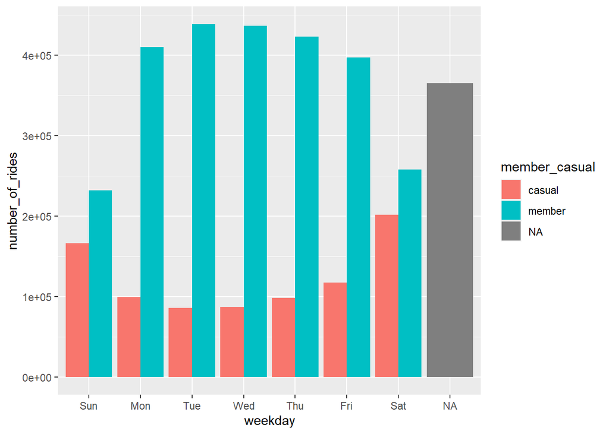

```r
all_trips_v2 %>%
  mutate(weekday = wday(started_at, label = TRUE)) %>%
  group_by(member_casual, weekday) %>%
  summarise(number_of_rides = n()
            ,average_duration = mean(ride_length)) %>%
  arrange(member_casual, weekday)  %>%
  ggplot(aes(x = weekday, y = number_of_rides, fill = member_casual)) +
  geom_col(position = "dodge")
```

Create a visualization for average duration

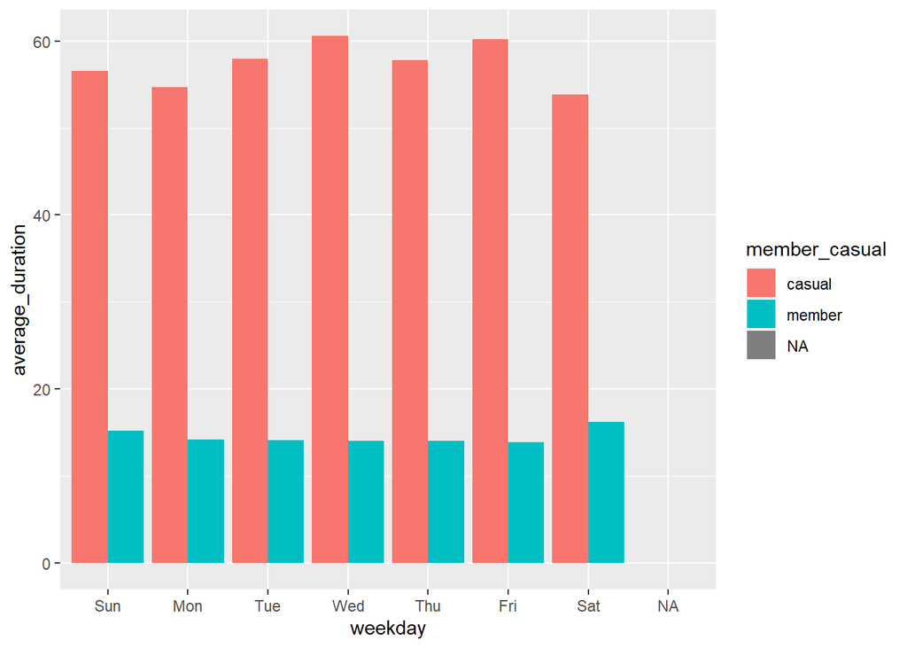

```r
all_trips_v2 %>%
  mutate(weekday = wday(started_at, label = TRUE)) %>%
  group_by(member_casual, weekday) %>%
  summarise(number_of_rides = n()
            ,average_duration = mean(ride_length)) %>%
  arrange(member_casual, weekday)  %>%
  ggplot(aes(x = weekday, y = average_duration, fill = member_casual)) +
  geom_col(position = "dodge")
```

# STEP 11 : Summarize for future analysis

```r
counts <- aggregate(all_trips_v2$ride_length ~ all_trips_v2$member_casual + all_trips_v2$day_of_week, FUN = mean)
write.csv(counts, file = 'D:\\Data Analytics certification\\Case Study\\avg_ride_length.csv')
```